# PS07 pre-lecture: sampling

## Sampling

simulating repeated samples with **moderndive**

the sampling distribution `p-hat`

- `rep_slice_sample()`
- `summarize()`
- `geom_histogram()`

A bowl of red and white balls, sampled over and over

## Four words

Population, Sample, Parameter, Statistic

- The **population** is every case you care about. Usually unseen.
- A **sample** is the subset you actually measured.
- A **parameter** describes the population. You want it, you rarely have it.
- A **statistic** describes the sample. You compute it, and it varies.

## rep_slice_sample()

Sample Again & Again

## rep_slice_sample()

Example

the population to sample from

```r
virtual_shovel <- bowl |>
  rep_slice_sample(n = 50)
```

the verb (function) how many balls in one scoop

## summarize()

Example

```r
virtual_shovel |>
  summarize(prop_red = mean(color == "red"))
```

the verb (function) what to call the result the proportion that are red

## reps =

Example

```r
virtual_samples <- bowl |>
  rep_slice_sample(n = 50, reps = 1000)

virtual_prop_red <- virtual_samples |>
  summarize(prop_red = mean(color == "red"))
```

one proportion per replicate

1,000 separate samples

## sampling distribution

How Much Does It Vary?

Its center sits near the parameter. Its spread is the standard error.

## geom_histogram()

Example

the statistic, not the data

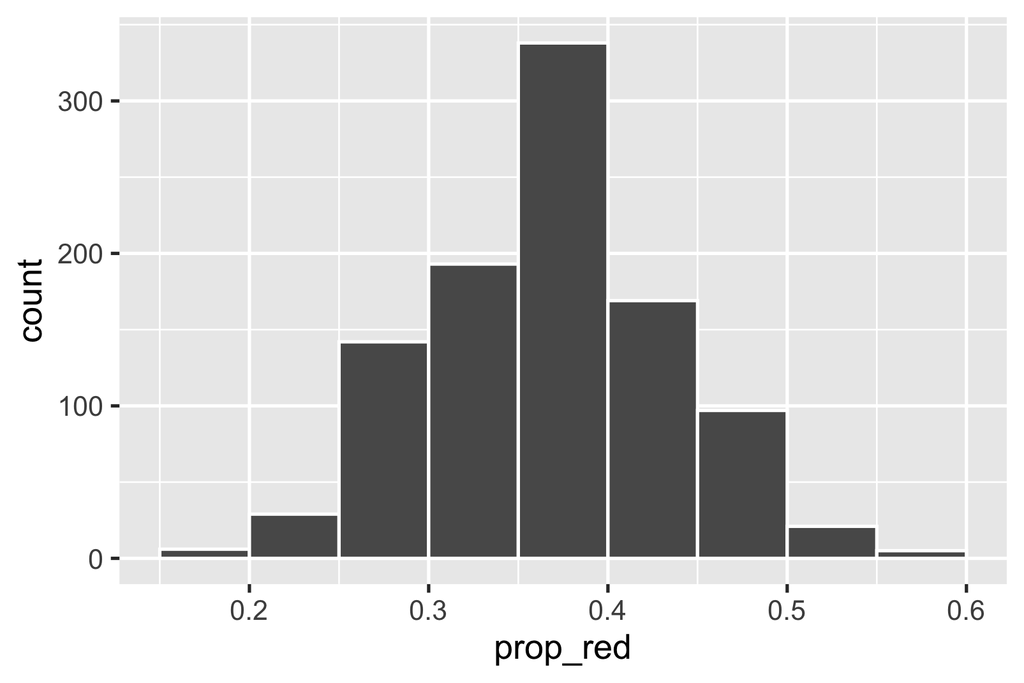

```r
ggplot(virtual_prop_red, aes(x = prop_red)) +
  geom_histogram(binwidth = 0.05, boundary = 0.4, color = "white")
```

bin width

## Standard error

The Spread Of The Estimate

- The **standard error** is the standard deviation of the sampling distribution.
- Bigger samples give a **narrower** sampling distribution.
- Quadruple the sample size to halve the standard error.
- The center barely moves; only the spread changes.

## The Central Limit Theorem

Bell-Shaped, Eventually

- As the sample size grows, the sampling distribution of the **mean** becomes bell-shaped.
- This holds even when the population itself is skewed.
- It is what lets a single sample say something about the population.
- The next chapter turns that into a **confidence interval**.